# အမည်ပေး ကင်ပွန်းတပ် ဖိတ်ကြားလွှာ

RQuesT

2026-07-06

ချစ်လှစွာသော ဆရာဝန်၊ ဆရာမများရှင်…

ဆယ်စုနှစ်ပေါင်းများစွာ ကျွန်မတို့ လူနာပျိုမဒီနဲ့ မဟေသီလေးတွေရဲ့ ကိုယ်စိတ်နှစ်ပါးကို ဒုက္ခပေးနေတဲ့ “ပိကော့ (PCOS)” ကို အခုဆိုရင် ပိုပြီး ပြည့်စုံတိကျတဲ့ အမည်သစ်လေးတစ်ခု ပေးလိုက်နိုင်ပြီမို့လို့ အမည်ပေး ကင်ပွန်းတပ်ပွဲလေး ဖိတ်ကြားအပ်ပါတယ်ရှင်။

ဒီနာမည်သစ်လေး ရဖို့အတွက် ဆေးပညာရှင်တွေ၊ ကျန်းမာရေးလုပ်သားတွေဟာ ကိုယ်တွေ့ခံစားနေရတဲ့ လူနာတွေနဲ့အတူ လက်တွဲပြီး ၁၄ နှစ်တိုင်တိုင် စနစ်တကျ သုတေသနပြု၊ စစ်တမ်းကောက်ပြီး တွက်ချက်ရွေးချယ်ခဲ့ကြတာပါ။ ၂၀၂၆ ခုနှစ် မေလ (၁၂) ရက်နေ့မှာတော့ The Lancet Journal ကနေတစ်ဆင့် တစ်ကမ္ဘာလုံးဆိုင်ရာ သဘောတူညီချက် (Global Consensus) နဲ့အတူ မိတ်ဆက်ပေးလိုက်ပြီ ဖြစ်ပါတယ်။

ကျွန်မတို့ ချစ်လှစွာသော “ပိကော့” ကို ပေးလိုက်တဲ့ နာမည်အသစ်လေးကတော့… ✨ “Polyendocrine Metabolic Ovarian Syndrome (PMOS)” (ပီးမော့စ်) ပါတဲ့ရှင်။

## 🛑 နာမည်ဟောင်းရဲ့ ပြဿနာ (The Misleading Legacy of PCOS)

သူ့ကို နာမည်ပြောင်းဖို့ ဘာလို့ ၁၄ နှစ်တိုင်တိုင် အချိန်ယူ ကြိုးစားခဲ့ရတာလဲ?

တကယ်တော့ “Polycystic Ovarian Syndrome” ဆိုတဲ့ နာမည်ဟောင်းက ဆရာဝန်တွေရော၊ လူနာတွေကိုပါ တော်တော်လေး လမ်းပျောက်စေခဲ့လို့ပါပဲ။ “Polycystic” လို့ ပြောလိုက်တာနဲ့ လူနာကော ဆရာဝန်ပါ အာထရာဆောင်း (Ultrasound) ရိုက်ပြီး အမျိုးသမီးတွေရဲ့ မျိုးဥအိမ်က “အလုံးတွေ၊ အရည်အိတ်တွေ” ကိုပဲ ရှာဖို့ စိတ်စောသွားကြပါတယ်။

တကယ့်လက်တွေ့မှာတော့ ဒါတွေက ရောဂါဖြစ်စေတဲ့ “Cysts (အရည်အိတ်)” တွေ မဟုတ်ဘဲ၊ ဟော်မုန်းမမျှတမှုကြောင့် သီးချိန်တန်မသီးနိုင် ပွင့်ချိန်တန် မပွင့်နိုင်တဲ့ မျိုးဥမွှာလေးတွေ (Arrested Follicles) သာ ဖြစ်ပါတယ်။ ပိုဆိုးတာက ဒီရောဂါ ခံစားနေရတဲ့ အမျိုးသမီး အချို့ရဲ့ မျိုးဥအိမ်မှာ အရည်အိတ် လုံးဝမရှိဘဲ ဖြစ်နေတတ်တာပါ။

နာမည်ကပေးတဲ့ လမ်းလွဲမှုကြောင့် ဖြစ်ရတဲ့ ဆိုးကျိုးတွေကလည်း မနည်းပါဘူး။

- ရောဂါရှာဖွေမှု နောက်ကျခြင်း : ရောဂါခံစားနေရသူတွေရဲ့ $70\%$ လောက်ဟာ လွဲမှားတဲ့ ဆေးဘက်ဆိုင်ရာ အယူအဆတွေကြောင့် ကိုယ့်မှာ ရောဂါရှိနေမှန်းတောင် မသိဘဲ နေခဲ့ကြရတာပါ။(Figure 1)

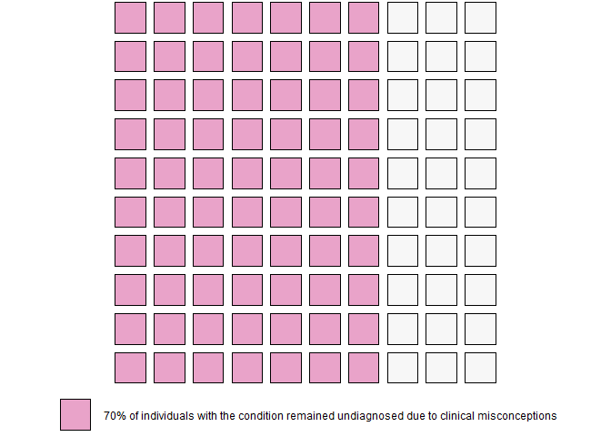

Figure 1

အမေရိကန်က Chelle ဆိုတဲ့ အမျိုးသမီးဟာ ရောဂါလက္ခဏာတွေ စုံနေပေမဲ့ “မျိုးဥအိမ်မှာ Cyst မရှိဘူး” ဆိုတဲ့ အယူအဆအမှားကြောင့် တိကျတဲ့ Diagnosis ရဖို့ ၁၀ နှစ်နီးပါး စောင့်ဆိုင်းခဲ့ရရှာပါတယ်။

> “ကျွန်မရဲ့ ဆုံးဖြတ်ချက်တွေ တော်တော်များများကို ဒီရောဂါက ထိန်းချုပ်ခဲ့တာပါ။ အမြဲတမ်း ပင်ပန်းနွမ်းနယ်မနေခဲ့ဘူးဆိုရင် ဘဝမှာ ဒီထက်မက အများကြီး လုပ်နိုင်ခဲ့မှာလို့ ခံစားရတယ်။ PCOS ကြောင့် ကျွန်မရဲ့ ခွန်အားတွေ တစ်နည်းမဟုတ်တစ်နည်းနဲ့ ကုန်ခမ်းနေခဲ့ရတာလေ။ ရောဂါလက္ခဏာတွေကတော့ အသက် ၁၁၊ ၁၂၊ ၁၃ နှစ်လောက်ကတည်းက စပြခဲ့တာ။ ဒါပေမဲ့ အဲဒီလောက် အရွယ်ငယ်ငယ်နဲ့ လက္ခဏာတွေပြတော့၊ အထူးသဖြင့် အဲဒီတုန်းက ဆရာဝန်တွေက ဒီရောဂါအကြောင်း သိပ်မသိကြသေးဘူး။ တော်တော်လေး ငြင်းပယ်တာတွေ ကြုံခဲ့ရတယ်။ သူတို့ ကျွန်မကို တိကျတဲ့ ရောဂါအမည် (Diagnosis) လုံးဝမပေးခဲ့ဘူး။ ပေးတာဆိုလို့ ‘ကဲ… ဒါက ကိုယ်ဝန်တားဆေး၊ ဒါကတော့ Insulin resistance အတွက် metformin’ ဆိုပြီး ဒါပါပဲ။ အဲဒီလိုနဲ့ ၁၀ နှစ်နီးပါး ဖြတ်သန်းခဲ့ရတယ်။ တကယ်လို့ တိကျတဲ့ Diagnosis သာ မရရင် ထိရောက်တဲ့ ကုသမှုကိုလည်း ရမှာမဟုတ်ပါဘူး။ အထူးသဖြင့် ကျွန်မရှိနေတဲ့ အမေရိကမှာပေါ့။ တကယ်ကို စိတ်ပျက်စရာကောင်းပြီး ခက်ခဲကြမ်းတမ်းလွန်းတဲ့ ခရီးလမ်းတစ်ခုပါပဲ။”

> — Chelle (အမေရိကန်နိုင်ငံမှ PCOS ဝေဒနာရှင် အမျိုးသမီးတစ်ဦး)
- Stigma (လူမှုပတ်ဝန်းကျင်ရဲ့ အထင်အမြင်လွဲမှားမှု): Jenef ဆိုတဲ့ မိန်းကလေးဆိုရင်လည်း ငယ်စဉ်ကတည်းက မျက်နှာမှာ ယောကျာ်းလေးတွေလို မုတ်ဆိတ်မွှေးတွေ မြန်မြန်ဆန်ဆန် ထွက်လာပြီး ကိုယ်အလေးချိန်တက်တာတွေကြောင့် မိမိကိုယ်မိမိ ယုံကြည်မှု ပျောက်ဆုံးကာ အမျိုးသမီးဆန်မှုနဲ့ ပတ်သက်လို့ စိတ်ဒဏ်ရာတွေ အများကြီး ရခဲ့ရရှာပါတယ်။

> “ကျွန်မရဲ့ ရောဂါလက္ခဏာတွေကို တော်တော်ငယ်ငယ်လေး၊ အပျိုဖော်ဝင်စ အရွယ်လောက်ကတည်းက စပြီး တွေ့ခဲ့ရတာပါ။ အသက် ၁၂ နှစ်၊ ၁၃ နှစ်လောက်မှာ မျက်နှာမှာ အမွှေးအမျှင်တွေ စထွက်လာပြီး ကိုယ့်ရဲ့အပြင်ပန်းက သိသာတဲ့ လက္ခဏာတွေကို စပြီး သတိထားမိခဲ့တယ်။ အဲဒါက ကိုယ့်ကိုယ်ကိုယ်ကော၊ ကိုယ့်ရဲ့ မိန်းကလေးဆန်မှုအပေါ်မှာပါ အတော်ကြာအောင် သံသယဖြစ်ခဲ့ရပါတယ်။ အခုထက်ထိလည်း မျက်နှာမှာ အမွှေးတွေက အရမ်းမြန်မြန် ထွက်လာနေတုန်းပဲ။ ဒီကြားထဲမှာ ကိုယ့်ကိုယ်ကိုယ် ယုံကြည်မှု ပြန်ရဖို့နဲ့ အမျိုးသမီးတစ်ယောက်အနေနဲ့ စိတ်လုံခြုံမှုရှိတယ်လို့ ခံစားရဖို့အတွက် ကျွန်မ အများကြီး ကြိုးစားရုန်းကန်နေရတုန်းပါပဲ။ ဒါ့အပြင် ကျွန်မအတွက် အမြဲတမ်း အခက်ခဲဆုံး ဖြစ်ခဲ့ရတာက ကိုယ်အလေးချိန်တက်တာ၊ ဗိုက်ကယ်ဗိုက်ပွတာနဲ့ အဲဒီလို ဖြစ်နေတဲ့အပေါ်မှာ ကိုယ့်ကိုယ်ကိုယ် ပြန်မြင်ပြီး စိတ်ပျက်အားငယ်ရတာတွေပါပဲ။”

> — Jenef (ဗြိတိန်နိုင်ငံမှ PCOS ဝေဒနာရှင် အမျိုးသမီးတစ်ဦး)

## 🤝 PMOS နဲ့ မိတ်ဆက်ပေးခြင်း (Meet Polyendocrine Metabolic Ovarian Syndrome)

ဒါကြောင့်လည်း ဆေးပညာရှင်တွေပါဝင်တဲ့ အဖွဲ့အစည်း ၅၆ ခုနဲ့ ကမ္ဘာ့တိုက်ကြီး ၆ တိုက်က လူနာပေါင်း ၂၂,၀၀၀ ကျော် ပါဝင်တဲ့ အင်အားစုကြီးက ၁၄ နှစ်တိုင်တိုင် ကြိုးစားပြီး ဒီနာမည်သစ် PMOS ကို တရားဝင် ပြောင်းလဲသတ်မှတ်ပေးခဲ့တာ ဖြစ်ပါတယ်။

“PMOS” ဆိုတဲ့ နာမည်က ဘာကြောင့် ပိုပြီး ကောင်းမွန် သင့်တော်ရသလဲဆိုရင်-

Polyendocrine (ဟော်မုန်းစနစ်တစ်ခုမက ချို့ယွင်းမှု): မျိုးဥအိမ်တစ်ခုတည်းတင် မဟုတ်ဘဲ Hypothalamic-Pituitary-Ovarian Axis၊ Adrenal Gland နှင့် Insulin Signaling Pathway စတဲ့ ဟော်မုန်းစနစ်မျိုးစုံ ရှုပ်ထွေးပတ်သက်နေမှုကို မီးမောင်းထိုးပြနိုင်ပါတယ်။

Ovarian Syndrome: မျိုးပွားမှုဆိုင်ရာ လက္ခဏာတွေ၊ မျိုးအောင်နိုင်စွမ်း (Fertility) ကိုလည်း အလေးထားဆဲ ဖြစ်ကြောင်း ဖော်ပြပါတယ်။

အထူးသဖြင့် ဆေးခန်းလာရင် Cyst မရှိပေမဲ့ Insulin Resistance ကြီးမားနေတဲ့ Non-polycystic Phenotype တွေကို ဆရာတို့ ပိုဂရုစိုက်မိလာစေမှာ ဖြစ်ပါတယ်ရှင်။

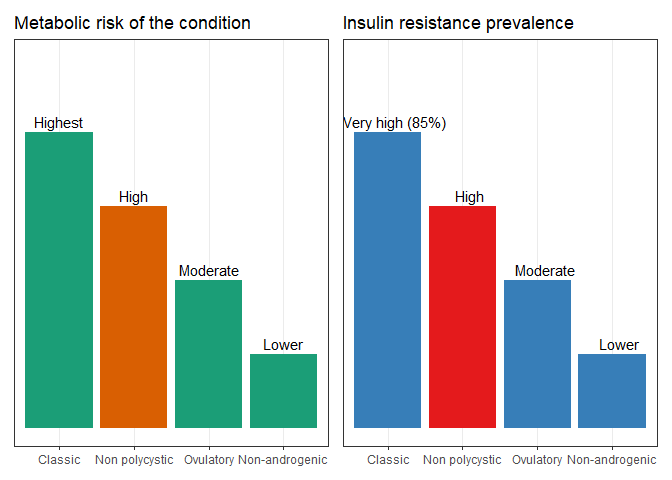

Figure 2

## ⚕️ ဆေးပညာကုဒ် (Medical Coding) နှင့် အာမခံ (Insurance) ပြဿနာပြေလည်ခြင်း

ယခင်က ရောဂါကို “မျိုးဥအိမ်ပြဿနာ (Gynecological Issue)” သက်သက်အဖြစ် သတ်မှတ်ထားတာကြောင့် ဆေးဘက်ဆိုင်ရာ ကုဒ် (Medical Coding) အရ အာမခံကုမ္ပဏီတွေက မျိုးပွားခြင်းနဲ့ မဆိုင်တဲ့ လက္ခဏာတွေ (ဥပမာ- နာတာရှည် ပင်ပန်းနွမ်းနယ်တာ၊ ဇီဝကမ္မဖြစ်စဉ်ပြဿနာတွေ) အတွက် ကုသစရိတ်တွေ ပေးလျော်ဖို့ ငြင်းဆန်လေ့ ရှိကြပါတယ်။

အခု PMOS ဆိုတဲ့ အမည်သစ်ကြောင့် ဒီဇီဝကမ္မလက္ခဏာတွေအတွက်ပါ ဆေးကုသမှု အာမခံ ပိုမိုရရှိလာနိုင်တော့မဲ့ အပြင်၊ Multi-disciplinary Care (Gynaecologist, Endocrinologist နဲ့ Cardiologist တွေရဲ့ ပူးပေါင်းကုသမှု) ကို ပိုမို စနစ်တကျ လုပ်ဆောင်လာနိုင်တော့မှာ ဖြစ်ပါတယ်ရှင်။

## 🗓️ ၁၄ နှစ်တာ ခရီးလမ်းနဲ့ တစ်ကမ္ဘာလုံးဆိုင်ရာ ဘုံသဘောတူညီချက် (The 14-Year Journey & Global Consensus)

ဒီအမည်သစ်လေး ဖြစ်တည်လာဖို့ ဖြတ်သန်းခဲ့ရတဲ့ သမိုင်းကြောင်းကလည်း တကယ်မလွယ်ကူလှပါဘူးရှင်။ Figure 3 က Event Timeline လေးကို ကြည့်လိုက်မယ်ဆိုရင် ဆေးပညာရှင်တွေဟာ ၂၀၁၂ ခုနှစ် NIH ရဲ့ စတင်အကြံပြုချက်ကတည်းက ကြိုးစားခဲ့ကြတာပါ။ ဒါပေမဲ့ ၂၀၁၃ ကနေ ၂၀၂၂ အထိ ဆယ်စုနှစ်တစ်ခုနီးပါး ကြိုးပမ်းမှုတွေက မအောင်မြင်ဘဲ ကျရှုံးခဲ့ရတာကို တွေ့ရမှာပါရှင်။ တော်တော်လေး စိတ်ပျက်စရာကောင်းခဲ့တဲ့ အချိန်တွေပေါ့နော်။

ဒါပေမယ့် လက်မလျှော့ဘဲ ၂၀၂၃ မှာ လူနာတွေနဲ့ ဆေးပညာရှင်တွေရဲ့ တစ်ခဲနက် ထောက်ခံမှုကို ရယူနိုင်ခဲ့ပြီး၊ ၂၀၂၅ ဧပြီမှာ ပထမဆုံးအကြိမ် ကမ္ဘာလုံးဆိုင်ရာ စစ်တမ်း (First Global Survey) ကောက်ယူနိုင်ခဲ့ပါတယ်။ အဲဒီနောက် နိုဝင်ဘာမှာ ပထမအကြိမ် ဆွေးနွေးညှိနှိုင်းမဲပေးခြင်း (First Nominal Group Process) ကို လုပ်ဆောင်ခဲ့ပါတယ်။ အဲဒီကနေတစ်ဆင့် ၂၀၂၆ ဇန်နဝါရီနဲ့ ဖေဖော်ဝါရီလတွေမှာ ဒုတိယအကြိမ် စစ်တမ်းနဲ့ ဆွေးနွေးညှိနှိုင်းမဲပေးခြင်းတွေကို အဆင့်ဆင့် လုပ်ဆောင်ခဲ့ပြီးတဲ့နောက်… နောက်ဆုံး ၂၀၂၆ မေလမှာတော့ အောင်အောင်မြင်မြင်နဲ့ တစ်ကမ္ဘာလုံးဆိုင်ရာ သဘောတူညီချက်ရရှိပြီး Lancet Journal မှာ တရားဝင် ဖော်ပြနိုင်ခဲ့တာ ဖြစ်ပါတယ်ရှင်။

[figure not shown]

Figure 3

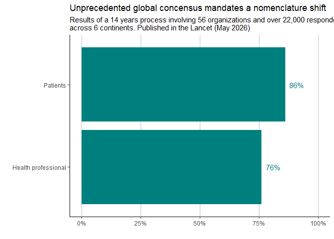

Figure 4

## 💌 နိဂုံးနှုတ်ဆက်နှင့် ဆော်ဩချက် (Call to Action)

ဒီအမည်သစ် PMOS ကို ၂၀၂၆ ခုနှစ် မေလကစပြီး နောက် ၃ နှစ်အတွင်း (၂၀၂၈ ခုနှစ် International guidelines တွေထွက်ရှိချိန်အထိ) စနစ်တကျ တဖြည်းဖြည်း အသွင်ကူးပြောင်း သုံးစွဲသွားကြမှာ ဖြစ်ပါတယ်။

ဒါကြောင့် ဆရာဝန်, ဆရာမကြီးများရှင်… နောက်နောင် ဆေးခန်းမှာ ပျိုမဒီလေးတွေနဲ့ မဟေသီမမတွေကို ရှင်းပြတဲ့အခါမှာဖြစ်ဖြစ်၊ ရောဂါရှာဖွေတဲ့အခါမှာဖြစ်ဖြစ် မျိုးဥအိမ်က Cyst ရှိ၊ မရှိ ထက်… ဇီဝကမ္မဖြစ်စဉ် (Metabolic) နဲ့ ဟော်မုန်း (Endocrine) စနစ်တွေကို ပိုမိုအသားပေး ဆွေးနွေးပေးကြဖို့ တိုက်တွန်းရင်း…

ကျွန်မတို့ရဲ့ “ပိကော့ (PCOS)” ကို “ပီမော့စ် (PMOS)” လို့ ပြောင်းလဲ ကင်ပွန်းတပ်ပွဲကို ဖိတ်ကြားလိုက်ရပါတယ်ရှင်။

ပျိုမဒီနဲ့ မဟေသီများအားလုံး ကျန်းမာပျော်ရွှင်ကြပါစေရှင်။

## 📚 References

1. Teede H, Khomami M, Morman R et al. Polyendocrine metabolic ovarian syndrome, the new name for polycystic ovary syndrome: a multistep global consensus process. *The Lancet*, 2026; 407, 2329-2339.
2. [Will renaming PCOS help women get diagnosed?](https://www.youtube.com/watch?v=A-V6rmpj9XM) - *What in the World* podcast, BBC World Service.